# Homework 06

**Question 1**

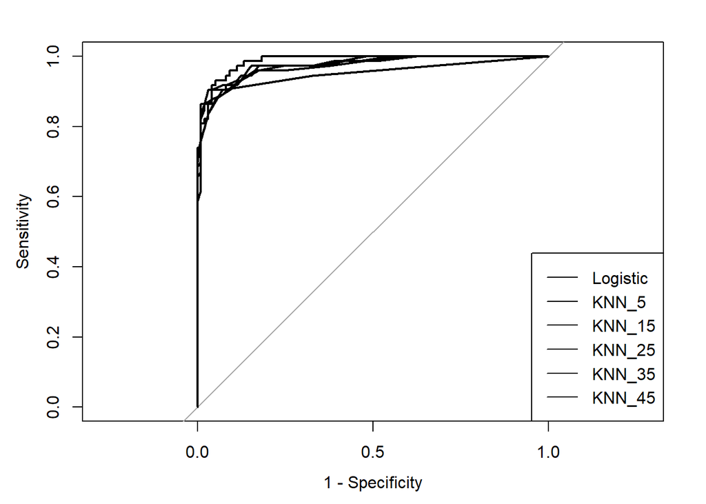

```r
library(pROC)
data <- read.csv("data/breast-cancer.csv")

set.seed(123)
train_id <- sample(1:nrow(data), 0.7 * nrow(data))

train <- data[train_id, ]
test <- data[-train_id, ]

xvars <- c("mean_radius", "mean_texture", "mean_smoothness")

m <- sapply(train[, xvars], mean)
s <- sapply(train[, xvars], sd)

train[, xvars] <- scale(train[, xvars], center = m, scale = s)
test[, xvars] <- scale(test[, xvars], center = m, scale = s)

log_fit <- glm(
  y ~ mean_radius + mean_texture + mean_smoothness,
  data = train,
  family = binomial
)

log_prob <- predict(log_fit, test, type = "response")

knn_prob <- function(k) {
  apply(test[, xvars], 1, function(x) {
    d <- rowSums((train[, xvars] - x)^2)
    mean(train$y[order(d)[1:k]])
  })
}

ks <- c(5, 15, 25, 35, 45)
knn_probs <- lapply(ks, knn_prob)

rocs <- c(
  list(Logistic = roc(test$y, log_prob)),
  setNames(lapply(knn_probs, function(p) roc(test$y, p)),
           paste0("KNN_", ks))
)
plot(rocs[[1]], legacy.axes = TRUE)

for (i in 2:length(rocs)) {
  plot(rocs[[i]], add = TRUE)
}

legend("bottomright", names(rocs), lty = 1)
```

```r
sapply(rocs, auc)
```

```
 Logistic     KNN_5    KNN_15    KNN_25    KNN_35    KNN_45
0.9865809 0.9503075 0.9705759 0.9731619 0.9767962 0.9756779
```

I prefer logistic regression because it has the highest AUC, 0.9866, among the six models. This indicates that it has the best overall ability to distinguish malignant from benign cases on the test data.

**Question 2**

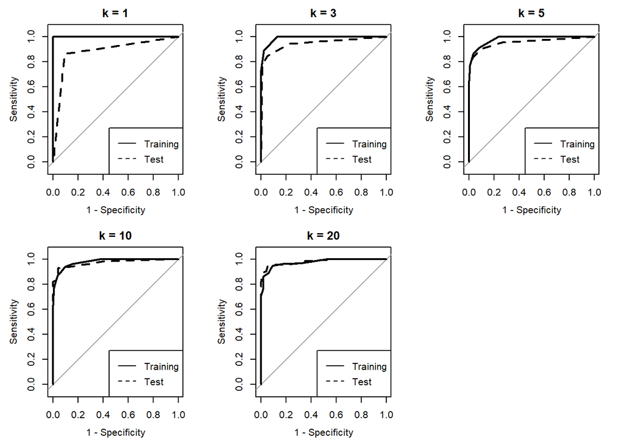

```r
ks2 <- c(1, 3, 5, 10, 20)

knn_prob2 <- function(train_x, train_y, new_x, k) {
  apply(new_x, 1, function(x) {
    d <- rowSums(sweep(train_x, 2, x)^2)
    mean(train_y[order(d)[1:k]])
  })
}

train_x <- as.matrix(train[, xvars])
test_x <- as.matrix(test[, xvars])

train_probs <- lapply(ks2, function(k)
  knn_prob2(train_x, train$y, train_x, k))

test_probs <- lapply(ks2, function(k)
  knn_prob2(train_x, train$y, test_x, k))

train_rocs <- lapply(train_probs, function(p)
  roc(train$y, p, quiet = TRUE))

test_rocs <- lapply(test_probs, function(p)
  roc(test$y, p, quiet = TRUE))

par(mfrow = c(2, 3))

for (i in 1:length(ks2)) {
  plot(train_rocs[[i]], legacy.axes = TRUE,
       main = paste("k =", ks2[i]))
  plot(test_rocs[[i]], add = TRUE, lty = 2)
  legend("bottomright",
         c("Training", "Test"),
         lty = c(1, 2))
}

par(mfrow = c(1, 1))
```

```r
data.frame(
  k = ks2,
  Train_AUC = sapply(train_rocs, auc),
  Test_AUC = sapply(test_rocs, auc)
)
```

```
   k Train_AUC  Test_AUC
1  1 1.0000000 0.8855885
2  3 0.9900419 0.9471624
3  5 0.9817783 0.9586245
4 10 0.9805005 0.9728823
5 20 0.9760562 0.9821079
```

At k=1, the training AUC is 1 because each training observation is its own nearest neighbor, so the training data are classified perfectly. However, the test AUC is much lower, showing that the model overfits the training data. As k increases, training AUC decreases slightly, while test AUC generally improves. This suggests that larger k values reduce overfitting and generalize better to new observations.

**Question 3**

1: The response to Question 5(b) is incomplete. The question asked the student to discuss their thoughts comparing the original plots and the ones ai created. I think you might accidentally miss the question. For correction, you can just compare the results and complete this part of the assignment.  
2: The Manhattan distance function is implemented incorrectly. It sums the raw coordinate differences and then takes a square root, instead of summing the absolute differences. In Question 4(a), the Manhattan distance is calculated incorrectly. The code uses sqrt(rowSums()), which corresponds to taking the square root of the sum of the raw differences. Manhattan distance should instead be the sum of the absolute differences, so the code should use rowSums(abs())